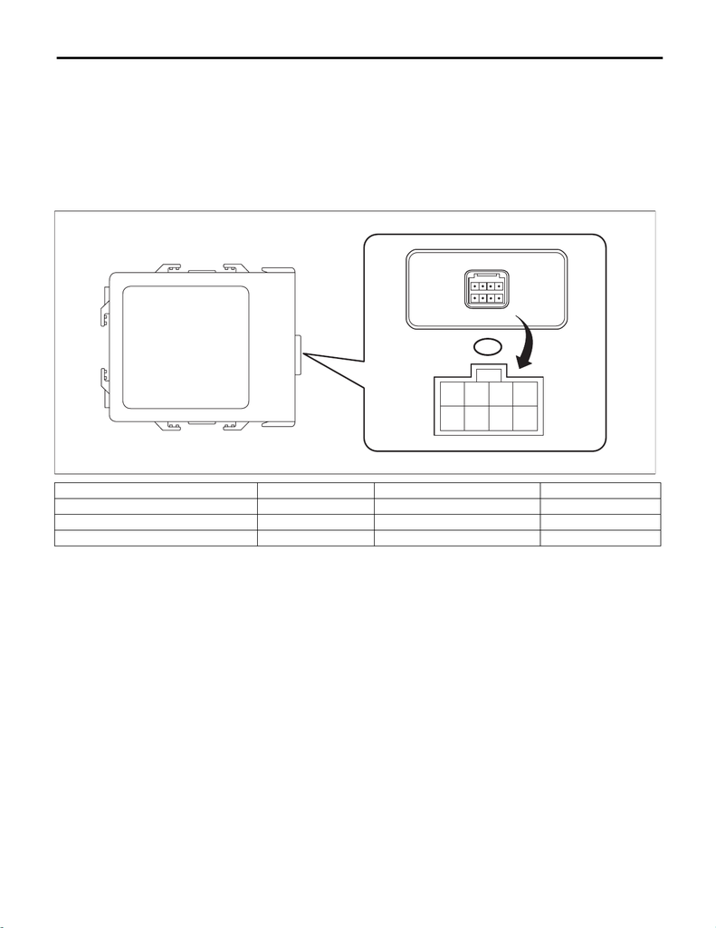

SL-15

Keyless Entry System

SECURITY AND LOCKS

4. Keyless Entry System

A: WIRING DIAGRAM

Refer to “Keyless Entry System” in the wiring diagram. <Ref. to WI-295, WIRING DIAGRAM, Keyless Entry

System.>

B: ELECTRICAL SPECIFICATION

1. KEYLESS ENTRY CONTROL MODULE

• Model without tire pressure monitoring system

Terminal No. Item Measuring condition Standard

3 (U-ART com.) — Cannot be measured —

4 (+B) ←→ Chassis ground Voltage Always 10 — 14 V

7 (GND) ←→ Chassis ground Resistance Always Less than 1 Ω

R80

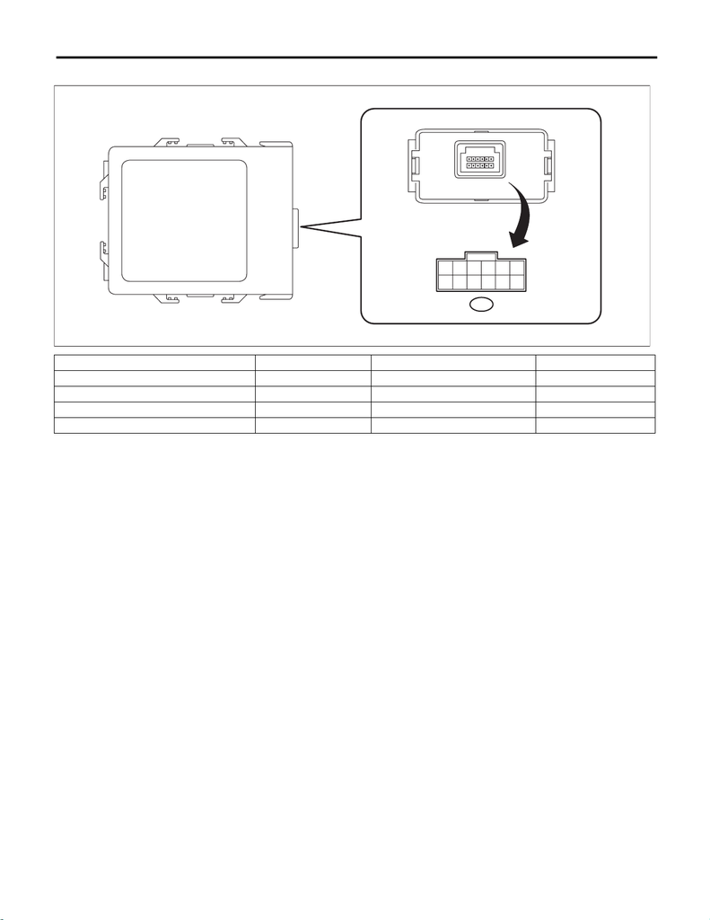

SL-16

Keyless Entry System

SECURITY AND LOCKS

• Model with tire pressure monitoring system

2. BODY INTEGRATED UNIT

Refer to “Control Module I/O Signal” of “BODY CONTROL SYSTEM (DIAGNOSTICS)” section. <Ref. to

BC(diag)-6, ELECTRICAL SPECIFICATION, Control Module I/O Signal.>

Terminal No. Item Measuring condition Standard

5 (GND) ←→ Chassis ground Resistance Always Less than 1 Ω

6 (+B) ←→ Chassis ground Voltage Always 10 — 14 V

11 (U-ART com.) — Cannot be measured —

5

9

8

7

R221

[figure not shown]

SL-17

Keyless Entry System

SECURITY AND LOCKS

C: INSPECTION

1. SYMPTOM CHART

Symptoms Repair order Reference

None of the functions of the keyless

entry system operate.

1. Check the keyless transmitter battery. <Ref. to SL-18, CHECK KEYLESS

TRANSMITTER BATTERY AND

FUNCTION, INSPECTION, Keyless

Entry System.>

2. Remove and visually inspect the following

fuses.

• No. 3 (in fuse & relay box)

• No. 7 (in fuse & relay box)

• No. 8 (in main fuse box)

If the fuse is blown out, replace the

fuse with a new part.

When there is no defective with the

fuse, check the power supply and

ground circuit. <Ref. to SL-11,

CHECK POWER SUPPLY AND

GROUND CIRCUIT, INSPECTION,

Door Lock Control System.>

3. Check the keyless entry control module. <Ref. to SL-19, CHECK KEYLESS

ENTRY CONTROL MODULE,

INSPECTION, Keyless Entry Sys-

tem.>

4. Check the power supply and ground circuit for

body integrated unit.

<Ref. to SL-19, CHECK BODY INTE-

GRATED UNIT POWER SUPPLY

AND GROUND CIRCUIT, INSPEC-

TION, Keyless Entry System.>

5. Check the key warning switch. <Ref. to SL-21, CHECK KEY WARN-

ING SWITCH, INSPECTION, Keyless

Entry System.>

6. Check the body integrated unit. <Ref. to BC(diag)-2, Basic Diagnostic

Procedure.>

The keyless transmitter cannot be

registered.

1. Check the keyless transmitter battery. <Ref. to SL-18, CHECK KEYLESS

TRANSMITTER BATTERY AND

FUNCTION, INSPECTION, Keyless

Entry System.>

2. Check the key warning switch. <Ref. to SL-21, CHECK KEY WARN-

ING SWITCH, INSPECTION, Keyless

Entry System.>

3. Check the keyless entry control module. <Ref. to SL-19, CHECK KEYLESS

ENTRY CONTROL MODULE,

INSPECTION, Keyless Entry Sys-

tem.>

4. Check the body integrated unit. <Ref. to BC(diag)-2, Basic Diagnostic

Procedure.>

Door lock or unlock does not operate.

NOTE:

If the door lock control system does

not operate when using the door lock

switch, check the door lock control

system. <Ref. to SL-10, INSPEC-

TION, Door Lock Control System.>

1. Check the keyless transmitter battery. <Ref. to SL-18, CHECK KEYLESS

TRANSMITTER BATTERY AND

FUNCTION, INSPECTION, Keyless

Entry System.>

2. Check the key warning switch. <Ref. to SL-21, CHECK KEY WARN-

ING SWITCH, INSPECTION, Keyless

Entry System.>

3. Check the door switch signal. <Ref. to SL-20, CHECK DOOR

SWITCH, INSPECTION, Keyless

Entry System.>

4. Check the keyless entry control module. <Ref. to SL-19, CHECK KEYLESS

ENTRY CONTROL MODULE,

INSPECTION, Keyless Entry Sys-

tem.>

5. Check the body integrated unit. <Ref. to BC(diag)-2, Basic Diagnostic

Procedure.>

[figure not shown]

SL-18

Keyless Entry System

SECURITY AND LOCKS

2. CHECK KEYLESS TRANSMITTER BATTERY AND FUNCTION

CAUTION:

Be sure to reset keyless transmitter of other vehicles registered to the inspection target vehicle, and

vehicles to which keyless transmitters were registered for inspection, to the condition before per-

forming the inspection. (Re-register the keyless transmitters.)

do not operate.

1. Check the keyless buzzer operation. <Ref. to SL-23, CHECK KEYLESS

BUZZER, INSPECTION, Keyless

Entry System.>

2. Check the hazard light operation. <Ref. to SL-22, CHECK HAZARD

LIGHT OPERATION, INSPECTION,

Keyless Entry System.>

3. Check the body integrated unit. <Ref. to BC(diag)-2, Basic Diagnostic

Procedure.>

Room light does not operate. 1. Check the room light operation. <Ref. to SL-22, CHECK ROOM

LIGHT OPERATION, INSPECTION,

Keyless Entry System.>

2. Check the body integrated unit. <Ref. to BC(diag)-2, Basic Diagnostic

Procedure.>

Ignition switch illumination does not

operate.

1. Check the ignition switch illumination. <Ref. to SL-24, CHECK IGNITION

SWITCH ILLUMINATION, INSPEC-

TION, Keyless Entry System.>

2. Check the body integrated unit. <Ref. to BC(diag)-2, Basic Diagnostic

Procedure.>

Step Check Yes No

1 CHECK KEYLESS TRANSMITTER BAT-

TERY.

1) Remove the battery from the keyless trans-

mitter. <Ref. to SL-82, REMOVAL, Keyless

Transmitter.>

2) Check the battery voltage. <Ref. to SL-83,

INSPECTION, Keyless Transmitter.>

Is the voltage 2.5 V or more? Go to step 2. Replace the key-

less transmitter

battery.

2 CHECK KEYLESS TRANSMITTER.

Register the keyless transmitter which operates

normally on other vehicles to the inspection tar-

get vehicle. <Ref. to SL-83, REGISTRATION

OF KEYLESS TRANSMITTER WITH SUBARU

SELECT MONITOR, REPLACEMENT, Keyless

Transmitter.>

1) Close all the doors and trunk lid of inspec-

tion target vehicle.

2) Using the keyless transmitter, lock and

unlock the doors, and unlock the trunk lid.

Can lock, unlock of doors and

unlock of the trunk lid be per-

formed properly on the inspec-

tion target vehicle?

Go to step 3. Due to vehicle mal-

function, continue

the keyless entry

system diagnosis.

3 CHECK KEYLESS TRANSMITTER.

Register the keyless transmitter of the

inspected vehicle to another vehicle whose key-

less system operates normally. <Ref. to SL-83,

REGISTRATION OF KEYLESS TRANSMIT-

TER WITH SUBARU SELECT MONITOR,

REPLACEMENT, Keyless Transmitter.>

Is the keyless transmitter regis-

tered correctly?

Go to step 4. Replace the key-

less transmitter

and perform regis-

tration.

4 CHECK KEYLESS TRANSMITTER.

Check the registered keyless transmitter.

1) Close all the doors and trunk lid of the vehi-

cle which keyless system operates normally.

2) Using the keyless transmitter, lock and

unlock the doors, and unlock the trunk lid.

Can lock, unlock of doors and

unlock of the trunk lid be per-

formed properly on the vehicle?

Keyless transmitter

is OK.

Replace the key-

less transmitter

and perform regis-

tration.

[figure not shown]

SL-19

Keyless Entry System

SECURITY AND LOCKS

4. CHECK BODY INTEGRATED UNIT POWER SUPPLY AND GROUND CIRCUIT

Refer to the “INSPECTION of POWER SUPPLY AND GROUND CIRCUIT” of “Door Lock Control System”

for detailed procedures. <Ref. to SL-11, CHECK POWER SUPPLY AND GROUND CIRCUIT, INSPECTION,

Door Lock Control System.>

Step Check Yes No

1 CHECK BODY INTEGRATED UNIT.

Read the DTC using Subaru Select Monitor.

NOTE:

For detailed procedures, refer to “PC applica-

tion help for Subaru Select Monitor”.

Is DTC U1500 “KEYLESS

UART COM. MALFUNCTION”

displayed?

Go to step 2. Keyless entry con-

trol module is nor-

mal.

2 CHECK POWER SUPPLY.

1) Disconnect the keyless entry control mod-

ule connector.

2) Measure the voltage between keyless entry

control module connector and chassis ground.

Connector & terminal

Model without tire pressure monitoring

system

(R80) No. 4 (+) — Chassis ground (–):

Model with tire pressure monitoring sys-

tem

(R221) No. 6 (+) — Chassis ground (–):

Is the voltage 10 V or more? Go to step 3. Check the harness

for open or short

circuits between

the keyless entry

control module and

the fuse.

3 CHECK GROUND CIRCUIT.

Measure the resistance between keyless entry

control module connector and chassis ground.

Connector & terminal

Model without tire pressure monitoring

system

(R80) No. 7 — Chassis ground:

Model with tire pressure monitoring sys-

tem

(R221) No. 5 — Chassis ground:

Ω?

Go to step 4. Repair or replace

the harness.

4 CHECK KEYLESS ENTRY CONTROL MOD-

ULE CIRCUIT.

1) Disconnect the body integrated unit connec-

tor.

2) Check the harness between keyless entry

control module and body integrated unit.

Connector & terminal

Model without tire pressure monitoring

system

(i171) No. 11 — (R80) No. 3:

Model with tire pressure monitoring sys-

tem

(i171) No. 11 — (R221) No. 11:

Is harness normal? Replace the key-

less entry control

module.

Repair or replace

the harness.

[figure not shown]

SL-20

Keyless Entry System

SECURITY AND LOCKS

5. CHECK DOOR SWITCH

Step Check Yes No

1 CHECK CURRENT DATA.

Display the following items using Subaru Select

Monitor.

• «Driver’s door SW input»

• «P-door SW input»

• «Rear right door SW input»

• «Rear left door SW input»

• «R Gate SW input»

NOTE:

For detailed procedures, refer to “PC applica-

tion help for Subaru Select Monitor”.

Does the display switch

between OFF ←→ ON when

each door or trunk lid is

opened/closed?

The door switch or

the trunk lid latch

switch is normal.

Go to step 2.

2 CHECK HARNESS.

1) Disconnect the connector of body inte-

grated unit.

2) Disconnect the connector of the door switch

or the trunk lid latch switch that the display does

not change.

3) Check the harness between body inte-

grated unit and defective switch.

Connector & terminal

Front door LH

(i84) No. 14 — (R9) No. 1:

Front door RH

(i84) No. 13 — (R12) No. 1:

Rear door LH

(i84) No. 24 — (R22) No. 1:

Rear door RH

(i84) No. 25 — (R16) No. 1:

Trunk lid

(i84) No. 33 — (R186) No. 3:

Is harness normal? Go to step 3. Repair or replace

the harness.

3 CHECK HARNESS.

Measure the resistance between the faulty

switch connector and chassis ground.

Connector & terminal

Front door LH

(R9) No. 3 — Chassis ground:

Front door RH

(R12) No. 3 — Chassis ground:

Rear door LH

(R22) No. 3 — Chassis ground:

Rear door RH

(R16) No. 3 — Chassis ground:

Trunk lid

(R186) No. 2 — Chassis ground:

Is the resistance less than 10

Ω?

Go to step 4. Repair or replace

the harness.

4 CHECK DOOR SWITCH.

Measure the resistance between faulty switch

terminals.

Terminals

Front LH door switch

No. 1 — No. 3:

Front RH door switch

No. 1 — No. 3:

Rear LH door switch

No. 1 — No. 3:

Rear RH door switch

No. 1 — No. 3:

Trunk lid latch switch

No. 3 — No. 2:

Is the resistance 1 MΩ or more

when the door switch is pushed

and the trunk lid is closed?

Replace the body

integrated unit.

<Ref. to SL-78,

Body Integrated

Unit.>

Replace the faulty

parts.

• Door switches

• Trunk lid latch

and actuator ASSY

[figure not shown]

SL-21

Keyless Entry System

SECURITY AND LOCKS

6. CHECK KEY WARNING SWITCH

Step Check Yes No

1 CHECK CURRENT DATA.

Using the Subaru Select Monitor, display the

data of «key-lock warning SW».

NOTE:

For detailed procedures, refer to “PC applica-

tion help for Subaru Select Monitor”.

Is the normal input signal dis-

played when the key is inserted

in/removed from the ignition

switch?

The key warning

switch is OK.

Go to step 2.

2 CHECK FUSE.

Remove and visually check fuse No. 14 (in the

main fuse box).

Is the fuse blown out? Replace the fuse

with a new part.

Go to step 3.

3 CHECK KEY WARNING SWITCH CIRCUIT.

1) Disconnect the connector of body inte-

grated unit.

2) Insert the key into ignition switch. (LOCK

position)

3) Measure the voltage between the body inte-

grated unit connector and chassis ground.

Connector & terminal

(B280) No. 4 (+) — Chassis ground (–):

Is the voltage 9 V or more? Go to step 4. Go to step 5.

4 CHECK KEY WARNING SWITCH CIRCUIT.

1) Remove the key from ignition switch.

2) Measure the voltage between the body inte-

grated unit connector and chassis ground.

Connector & terminal

(B280) No. 4 (+) — Chassis ground (–):

Is the voltage less than 1.5 V? The key warning

switch is OK.

Go to step 5.

5 CHECK KEY WARNING SWITCH.

1) Disconnect the connector of key warning

switch.

2) Insert the key into ignition switch. (LOCK

position)

3) Measure the resistance between key warn-

ing switch terminals.

Terminals

No. 1 — No. 2:

Is the resistance less than 1 Ω? Go to step 6. Replace the key

warning switch.

6 CHECK KEY WARNING SWITCH.

1) Remove the key from ignition switch.

2) Measure the resistance between key warn-

ing switch terminals.

Terminals

No. 1 — No. 2:

Is the resistance 1 MΩ or

more?

Check the follow-

ing:

• Harness for

open circuits and

shorts between the

key warning switch

and fuse.

• Harness for

open or short

between the body

integrated unit and

key warning switch

Replace the key

warning switch.

[figure not shown]

SL-22

Keyless Entry System

SECURITY AND LOCKS

7. CHECK ROOM LIGHT OPERATION

8. CHECK HAZARD LIGHT OPERATION

Step Check Yes No

1 CHECK ROOM LIGHT OPERATION.

Make sure the room light illuminates when the

room light switch is ON, and goes off when the

switch is OFF.

Does the room light illuminate

or go off?

Go to step 2. Check the room

light circuit. <Ref.

to LI-63, INSPEC-

TION, Room

Light.>

2 CHECK ROOM LIGHT OPERATION.

1) Turn the room light switch to the “DOOR”

position.

2) Open and close any door.

Does the room light illuminate

←→ go off (including off delay)

when the door is opened and

closed?

Go to step 3. Go to step 4.

3 CHECK KEYLESS ENTRY OPERATION.

Press the LOCK/UNLOCK button of the keyless

transmitter.

Does it operate properly? Room light is nor-

mal.

Check keyless

entry system.

<Ref. to SL-17,

SYMPTOM

CHART, INSPEC-

TION, Keyless

Entry System.>

4 CHECK ROOM LIGHT.

Check the room light. <Ref. to LI-63, INSPEC-

TION, Room Light.>

Is room light normal? Go to step 5. Replace the bulb

or room light

assembly.

5 CHECK HARNESS.

1) Disconnect the connectors of body inte-

grated unit and room light.

2) Check the harness between body inte-

grated unit and room light.

Connector & terminal

(i84) No. 4 — (R52) No. 2:

Is harness normal? Go to step 6. Repair or replace

the harness.

6 CHECK HARNESS.

Measure the voltage between the room light

connector and chassis ground.

Connector & terminal

(R52) No. 3 (+) — Chassis ground (–):

Is the voltage 10 V or more? Replace the body

integrated unit.

<Ref. to SL-78,

Body Integrated

Unit.>

Repair or replace

the harness.

Step Check Yes No

1 CHECK HAZARD LIGHT OPERATION.

Make sure the hazard light blinks when hazard

switch is turned to ON.

Does the hazard light blink? Go to step 2. Check the hazard

light circuit.

2 CHECK BODY INTEGRATED UNIT SETTING.

Display the data of «Abnormal warning lamp

flashing setting» using Subaru Select Monitor.

NOTE:

For detailed procedures, refer to “PC applica-

tion help for Subaru Select Monitor”.

Is the setting ON? Go to step 3. Turn the setting to

ON.

3 CHECK CURRENT DATA.

Display the data of «Hazard Output» using Sub-

aru Select Monitor.

Is output signal present when

operating the transmitter

LOCK/UNLOCK button?

Go to step 4. Go to step 5.

4 CHECK KEYLESS ENTRY OPERATION.

Press the LOCK/UNLOCK button of the keyless

transmitter.

Does it operate properly? Replace the body

integrated unit.

<Ref. to SL-78,

Body Integrated

Unit.>

Check keyless

entry system.

<Ref. to SL-17,

SYMPTOM

CHART, INSPEC-

TION, Keyless

Entry System.>

[figure not shown]

SL-23

Keyless Entry System

SECURITY AND LOCKS

9. CHECK KEYLESS BUZZER

10.CHECK DOOR LOCK SWITCH

For operation procedures, refer to the “INSPECTION OF DOOR LOCK SWITCH” of the “Door Lock Control

System”. <Ref. to SL-11, CHECK DOOR LOCK SWITCH, INSPECTION, Door Lock Control System.>

1) Disconnect the connectors of the body inte-

grated unit and turn signal & hazard unit.

2) Check the harness between body inte-

grated unit and turn signal & hazard unit.

Connector & terminal

(i171) No. 18 — (B32) No. 8:

Is harness normal? Check body inte-

grated unit. <Ref.

to BC(diag)-2,

Basic Diagnostic

Procedure.>

Repair or replace

the harness.

Step Check Yes No

1 CHECK BODY INTEGRATED UNIT SETTING.

Display the data of «Answer-back buzzer

setup» using Subaru Select Monitor.

NOTE:

For detailed procedures, refer to “PC applica-

tion help for Subaru Select Monitor”.

Is the setting ON? Go to step 2. Turn the setting to

ON.

2 CHECK BODY INTEGRATED UNIT SETTING.

Display the data of «Keyless Buzzer Volume»

using Subaru Select Monitor.

Turn the setting to “7”.

Does the keyless buzzer

sound?

Set to the volume

that the customer

requested.

Go to step 3.

3 CHECK BODY INTEGRATED UNIT.

Select and perform the «Keyless Buzzer Out-

put» using Subaru Select Monitor.

Does the keyless buzzer

sound?

Check the keyless

control module.

Go to step 4.

4 CHECK KEYLESS BUZZER CIRCUIT.

1) Turn the ignition switch to OFF.

2) Disconnect the connectors of the body inte-

grated unit and keyless buzzer.

3) Check the harness between body inte-

grated unit and keyless buzzer.

Connector & terminal

(B280) No. 20 — (B164) No. 1:

Is harness normal? Go to step 5. Repair or replace

the harness.

5 CHECK HARNESS.

Measure the resistance between keyless

buzzer connector and chassis ground.

Connector & terminal

(B164) No. 1 — Chassis ground:

Is the resistance value 10 kΩ or

more?

Go to step 6. Repair or replace

the short circuit of

the harness.

6 CHECK KEYLESS BUZZER CIRCUIT.

Measure the resistance between the keyless

buzzer connector and chassis ground.

Connector & terminal

(B164) No. 2 — Chassis ground:

Is the resistance less than 10

Ω?

Go to step 7. Repair or replace

the harness.

7 CHECK BODY INTEGRATED UNIT.

1) Connect the connector of body integrated

unit.

2) Select and perform the «Keyless Buzzer

Output» using Subaru Select Monitor.

3) Measure the voltage between body inte-

grated unit connector and chassis ground using

an oscilloscope.

Connector & terminal

(B280) No. 20 (+) — Chassis ground (–):

Is the frequency 2 kHz or the

voltage 9 V or more?

Replace the key-

less buzzer.

Replace the body

integrated unit.

<Ref. to SL-78,

Body Integrated

Unit.>

[figure not shown]

SL-24

Keyless Entry System

SECURITY AND LOCKS

11.CHECK IGNITION SWITCH ILLUMINATION

Step Check Yes No

1 CHECK IGNITION CIRCUIT.

Check the ignition circuit. <Ref. to SL-31,

CHECK IGNITION SWITCH CIRCUIT,

INSPECTION, Security System.>

Is the switch circuit normal? Go to step 2. Repair or replace.

2 CHECK DOOR SWITCH CIRCUIT.

Inspect door switch circuit. <Ref. to SL-20,

CHECK DOOR SWITCH, INSPECTION, Key-

less Entry System.>

Is the switch circuit normal? Go to step 3. Repair or replace.

3 CHECK FUSE.

Remove and visually check fuse No. 14 (in the

main fuse box).

Is the fuse blown out? Replace the fuse

with a new part.

Go to step 4.

4 CHECK HARNESS.

1) Disconnect the ignition switch illumination

connector.

NOTE:

The ignition switch illumination is integrated into

the immobilizer antenna.

2) Measure the voltage between ignition

switch illumination connector and chassis

ground.

Connector & terminal

(B415) No. 2 (+) — Chassis ground (–):

Is the voltage 10 V or more? Go to step 5. Check the harness

for open or short

circuits between

the ignition switch

illumination and

fuse.

5 CHECK IGNITION SWITCH ILLUMINATION

CIRCUIT.

1) Disconnect the connector of body inte-

grated unit.

2) Check the harness between body inte-

grated unit and ignition switch illumination.

Connector & terminal

(B280) No. 25 — (B415) No. 6:

Is harness normal? Go to step 6. Check the harness

for open circuits

and shorts

between the body

integrated unit and

ignition switch illu-

mination.

6 CHECK IGNITION SWITCH ILLUMINATION

BULB.

Apply battery voltage between terminals of the

bulb.

Terminals

No. 2 (+) — No. 6 (–):

Does the bulb illuminate? Replace the body

integrated unit.

<Ref. to SL-78,

Body Integrated

Unit.>

Replace the immo-

bilizer antenna.

<Ref. to SL-88,

REMOVAL, Immo-

bilizer Antenna.>